Why you are looking at this data set?  
• What business question is driving the analysis?  
• How did you manipulate the original data?  
• What techniques you used and why (how do they relate to your questions)?  
• How well did the data mining techniques perform on your data set?  
o Accuracy Metrics and Stability (Hold out)  
• Recommendations for action  
• Conclusions  
• Next steps or follow up items for improvements

# Predict the usefulness of a review on Yelp

Group 9  
Chun Yin Wong / Rui Sun / Aisultan

## Objective

To predict a new review's usefulness according to its comment. This can help user filter out useless comments and understand the restaurant quickly.

We build a model based on historical comments and classify them into three classes, useless, useful, and very useful. We believe that it is necessary to separate like this to identify the outstanding comments. Our goal is to predict the class of a new comment when it appears. The original data base contains more than 5 million rows of comments. The first thing we need to do is to select 100k rows randomly to make the code runs faster.

```python
%matplotlib inline
import pandas as pd
import random

p = 0.02
# 1% of the lines
# keep the header, then take only 1% of lines
# if random from [0,1] interval is greater than 0.01 the row will be skipped
yelp = pd.read_csv('C:/Users/Ken/Desktop/MPM/Winter 2019/MEM 410/Final Project/yelp_review.csv',
                   header=0, skiprows=lambda i: i>0 and random.random() > p)
yelp.head()
```

|  | review_id | user_id | business_id | stars | date | text | useful | funny | cool |
| --- | --- | --- | --- | --- | --- | --- | --- | --- | --- |
| 0 | 7GsVl-wMaSfG1VoEK6-s6g | u0LXt3Uea_GidxRW1xcsfg | 3E5umUqaU5OZAV3jNLW3kQ | 4 | 2017-11-02 | Great place to bring dogs! It's really a dog p... | 0 | 0 | 0 |
| 1 | EKAN4jw3LsE3631feSaA_g | u0LXt3Uea_GidxRW1xcsfg | pZ1quwXnYozLIZIVABojhw | 4 | 2012-09-23 | My boyfriend took me here for my birthday. At ... | 0 | 0 | 0 |
| 2 | 0wsN8ZT101c8LhqwQZJjvw | u0LXt3Uea_GidxRW1xcsfg | kRdzgq-hr3amtTkQR-U7dw | 4 | 2013-05-01 | they have some pretty interesting things here!... | 0 | 0 | 0 |
| 3 | JCna3sfrjqtnsG7l-pSs-A | u0LXt3Uea_GidxRW1xcsfg | uATqc1QJkS5lOKfoJ6Uz2w | 3 | 2013-02-18 | Read about this bakery on BlogTO so decided to... | 2 | 0 | 1 |
| 4 | p9q6dgpCH05Avd4CKmumEA | u0LXt3Uea_GidxRW1xcsfg | n44grut83X0UiRZCA-O1fw | 3 | 2017-01-25 | Saw that this was in my neighbourhood so decid... | 0 | 0 | 0 |

Now we see the data frame. Some irrelavent columns are dropped.

```python
yelp = yelp.drop ('funny',axis=1)
yelp = yelp.drop ('cool', axis=1)
yelp = yelp.drop ('date',axis=1)
yelp.head()
```

|  | review_id | user_id | business_id | stars | text | useful |
| --- | --- | --- | --- | --- | --- | --- |
| 0 | 7GsVl-wMaSfG1VoEK6-s6g | u0LXt3Uea_GidxRW1xcsfg | 3E5umUqaU5OZAV3jNLW3kQ | 4 | Great place to bring dogs! It's really a dog p... | 0 |
| 1 | EKAN4jw3LsE3631feSaA_g | u0LXt3Uea_GidxRW1xcsfg | pZ1quwXnYozLIZIVABojhw | 4 | My boyfriend took me here for my birthday. At ... | 0 |
| 2 | 0wsN8ZT101c8LhqwQZJjvw | u0LXt3Uea_GidxRW1xcsfg | kRdzgq-hr3amtTkQR-U7dw | 4 | they have some pretty interesting things here!... | 0 |
| 3 | JCna3sfrjqtnsG7l-pSs-A | u0LXt3Uea_GidxRW1xcsfg | uATqc1QJkS5lOKfoJ6Uz2w | 3 | Read about this bakery on BlogTO so decided to... | 2 |
| 4 | p9q6dgpCH05Avd4CKmumEA | u0LXt3Uea_GidxRW1xcsfg | n44grut83X0UiRZCA-O1fw | 3 | Saw that this was in my neighbourhood so decid... | 0 |

Check the data to see for every useful vote, how many comments are there. Show the top 10 of the list.

```
useful
0    55304
1    22696
2    10829
3     5699
4     3373
5     2126
6     1345
7      937
8      672
9      502
dtype: int64
```

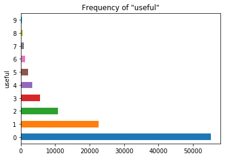

```python
freq = yelp.groupby('useful').size()[:10]
print(freq)
freq.plot('barh', title='Frequency of "useful"')
```

Nearly half of the comments have no useful vote. It means they should be useless. The purpose is to give us a direct judgement to set the range of each class.

We create a new column "usefulness" and categorize every comment into a class manually. In this column, 0 = useless, 1 = useful, and 2 = very useful.

```python
def usefulness(c):
    if c['useful'] == 0:
        return '0'
    elif 1 <= c['useful'] <= 5:
        return '1'
    else:
        return '2'

yelp['usefulness'] = yelp.apply(usefulness, axis=1)
yelp.head()
```

|  | review_id | user_id | business_id | stars | text | useful | usefulness |
| --- | --- | --- | --- | --- | --- | --- | --- |
| 0 | 7GsVl-wMaSfG1VoEK6-s6g | u0LXt3Uea_GidxRW1xcsfg | 3E5umUqaU5OZAV3jNLW3kQ | 4 | Great place to bring dogs! It's really a dog p... | 0 | 0 |
| 1 | EKAN4jw3LsE3631feSaA_g | u0LXt3Uea_GidxRW1xcsfg | pZ1quwXnYozLIZIVABojhw | 4 | My boyfriend took me here for my birthday. At ... | 0 | 0 |
| 2 | 0wsN8ZT101c8LhqwQZJjvw | u0LXt3Uea_GidxRW1xcsfg | kRdzgq-hr3amtTkQR-U7dw | 4 | they have some pretty interesting things here!... | 0 | 0 |
| 3 | JCna3sfrjqtnsG7l-pSs-A | u0LXt3Uea_GidxRW1xcsfg | uATqc1QJkS5lOKfoJ6Uz2w | 3 | Read about this bakery on BlogTO so decided to... | 2 | 1 |
| 4 | p9q6dgpCH05Avd4CKmumEA | u0LXt3Uea_GidxRW1xcsfg | n44grut83X0UiRZCA-O1fw | 3 | Saw that this was in my neighbourhood so decid... | 0 | 0 |

Now check the distribution to see if the manual classification make sense.

```
usefulness
0    55304
1    44723
2     5461
dtype: int64
```

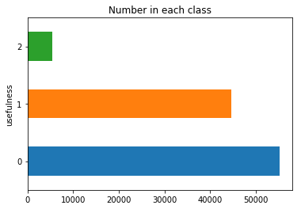

```python
X = yelp['text']
y = yelp['usefulness']

y_freq = yelp.groupby(y).size()
print(y_freq)
y_freq.plot('barh', title='Number in each class')
```

Now we do vectorization to convert words into numbers of 0 and 1.

from sklearn.feature_extraction.text import CountVectorizer vect = CountVectorizer() X_vect = count_vect.fit_transform(X)

Then use TFIDF transform to assign importance to each word.

from sklearn.feature_extraction.text import TfidfTransformer tfidf_transformer = TfidfTransformer() X_vect = tfidf_transformer.fit_transform(X)

Combine previous two stpes as TFIDF vectorization. After several trials, we decided to choose max_features as 10000 to show the best outcome.

```python
from sklearn.feature_extraction.text import TfidfVectorizer

vect = TfidfVectorizer(max_features=10000, stop_words=u'english')
X_trans = vect.fit_transform(X)
```

Find out top 10 important words.

```python
sum_words = X_trans.sum(axis=0)
top_words = [(word, sum_words[0, idx]) for word, idx in vect.vocabulary_.items()]
top_words = sorted(top_words, key = lambda x: x[1], reverse=True)

for n, i in zip(range(10), top_words):
    print(n, i)
```

```
0 ('food', 3355.7704063781016)
1 ('great', 3243.655116821663)
2 ('place', 3070.805357316808)
3 ('good', 3064.2680488035267)
4 ('service', 2579.8944013267906)
5 ('time', 2131.6843092789068)
6 ('like', 2027.3743689474625)
7 ('just', 1998.5065094210056)
8 ('really', 1811.1223294955228)
9 ('best', 1592.1411887802215)
```

Split data for training and testing.

```python
from sklearn.model_selection import train_test_split

X_train, X_test, y_train, y_test = train_test_split(X_trans, y, test_size=0.3, random_state=111)
```

Train Naive Bayes Classifier.

from sklearn.naive_bayes import MultinomialNB clf = MultinomialNB().fit(X_train, y_train)

Train LinearSVC classifier.

```python
from sklearn.svm import LinearSVC

clf =  LinearSVC().fit(X_train, y_train)
```

Test classifier.

```python
from sklearn.metrics import accuracy_score

y_pred = clf.predict(X_test)
print('Accuracy ', accuracy_score(y_pred, y_test))
```

```
Accuracy  0.5642240970708124
```

Cross validation.

```python
from sklearn.model_selection import cross_val_score

score = cross_val_score(clf, X_trans, y, cv=10, scoring='accuracy')
print(score)
```

```
[0.56847692 0.56815166 0.56161137 0.5751256  0.56901782 0.5665529
 0.5665529  0.56873341 0.57043989 0.56750095]
```

Compare the result to cross valication, our classifier is not overfitting.

Draw the confusion matrix.

```
Confusion matrix, without normalization
[[11721  4865    48]
 [ 7190  6074   121]
 [  484  1083    61]]
Normalized confusion matrix
[[0.7  0.29 0.  ]
 [0.54 0.45 0.01]
 [0.3  0.67 0.04]]
              precision    recall  f1-score   support

           0       0.60      0.70      0.65     16634
           1       0.51      0.45      0.48     13385
           2       0.27      0.04      0.07      1628

   micro avg       0.56      0.56      0.56     31647
   macro avg       0.46      0.40      0.40     31647
weighted avg       0.54      0.56      0.55     31647
```

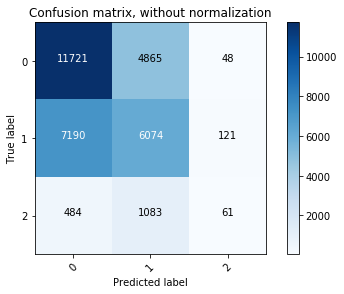

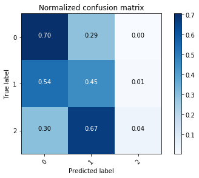

```python
import itertools
import numpy as np
import matplotlib.pyplot as plt
from sklearn.metrics import confusion_matrix, classification_report

def plot_confusion_matrix(cm, classes,normalize=False,title='Confusion matrix',cmap=plt.cm.Blues):

    if normalize:
        cm = cm.astype('float') / cm.sum(axis=1)[:, np.newaxis]
        print("Normalized confusion matrix")
    else:
        print('Confusion matrix, without normalization')

    print(cm)

    plt.imshow(cm, interpolation='nearest', cmap=cmap)
    plt.title(title)
    plt.colorbar()
    tick_marks = np.arange(len(classes))
    plt.xticks(tick_marks, classes, rotation=45)
    plt.yticks(tick_marks, classes)

    fmt = '.2f' if normalize else 'd'
    thresh = cm.max() / 2.
    for i, j in itertools.product(range(cm.shape[0]), range(cm.shape[1])):
        plt.text(j, i, format(cm[i, j], fmt),
                 horizontalalignment="center",
                 color="white" if cm[i, j] > thresh else "black")

    plt.tight_layout()
    plt.ylabel('True label')
    plt.xlabel('Predicted label')

# Compute confusion matrix
cnf_matrix = confusion_matrix(y_test, y_pred)
np.set_printoptions(precision=2)

# Plot non-normalized confusion matrix
plt.figure()
plot_confusion_matrix(cnf_matrix, classes=['0','1','2'],title='Confusion matrix, without normalization')

# Plot normalized confusion matrix
plt.figure()
plot_confusion_matrix(cnf_matrix, classes=['0','1','2'], normalize=True,title='Normalized confusion matrix')

print(classification_report(y_test, y_pred))
plt.show()
```

# Analysis

For the confusion matrix, we want more results are located in (0,0), (1,1), and (2,2) regions. However, it does not mean some other regions are not acceptable. Region (2,1) means the classifier categorizes very useful comments as useful and region (1,2) does it reversely. Although not accurate enough, we cannot treat them as mistakes because the classifier successfully distinguishes them from useless comments.

One of the reasons why the accuracy is not high is that the useful votes cannot reflect the true value of a comment despite it is probably the only thing that does. Most users just want to find a restaurant and know its rating. Or read the comments and leave them alone. Because to know whether a comment is useful or not, users have to try the restaurant by themselves first. But how many of them will open Yelp again and vote the comments after they finish the meals? As the result, probably a huge amount of comments which are supposed to be useful got no vote at all and this contradiction increases the difficulty of classification. We can know the consequence clearly in regions (1,0) and (0,1).

## Please see the next report! We used tokenization and Naive Bayes classifier.

# Recommendation

We can further clear the data and extract more useful words for better classification. Furthermore, we used the key words to develop a writing suggestion system to guide the users to write more useful comments based on historical comments and get more votes infuture.

# Conclusion

Despite the result does not meet our expectation, our classifier can still filter out most of useless comments and it is better than guessing.